# Queens and False Hydras

Estimating the value of fairy chess pieces.

2025-03-06

# Background Motivation

- Chess had become a spectator sport thanks to platforms like youtube and twitch.

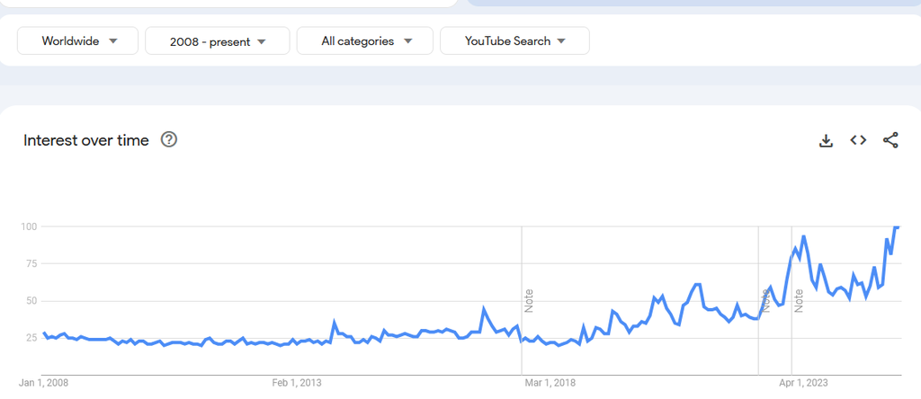

See “The Incredible/Insane business of chess” by Athletic Interest https://www.youtube.com/watch?v=XXuBH7JM5aA

# Background Motivation

Chess engines have gotten almost incomparably better than the best humans. So much so, that only by using weaker intermediary engines (or modern engines with restrictions) must be used in order to put humans and engines on the same Elo scale.

The most powerful open source engine is Stockfish, which uses a neural net, among other tricks like having a large library of openings and endgame hard coded in.

# Background Motivation

See the TCEC (Top Chess Engine Championship) at https://tcec-chess.com/

[figure not shown]

# Background Motivation

See also Elo World, by Tom Murphy VII, “Suckerpinch” at http://tom7.org/chess/

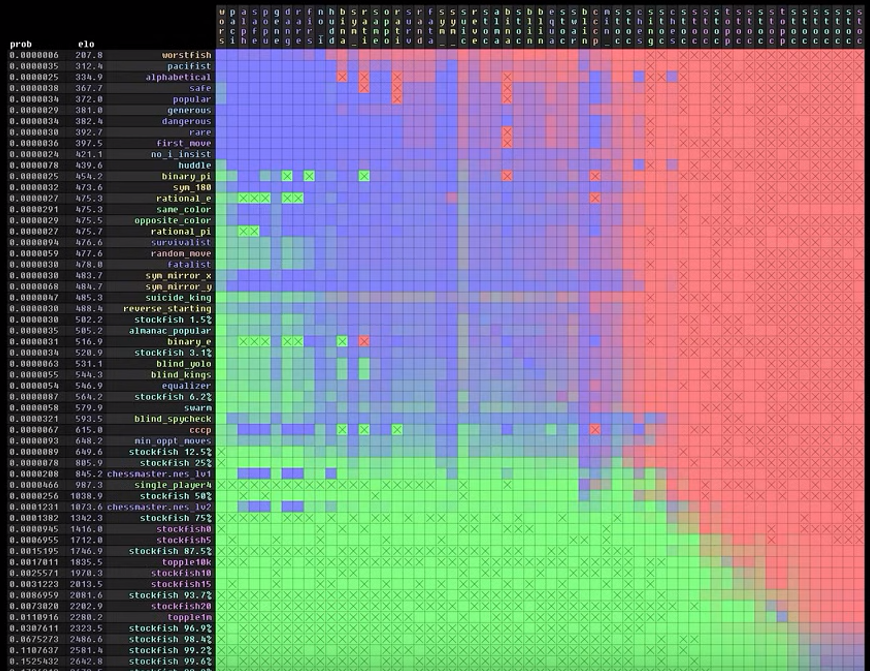

# Background Motivation

There has also been an explosion of published chess variants, many of which would considered types of fairy chess.

Fairy chess pieces include historical pieces that are no longer in standard chess, like the Ferz and Alfil of a predecessor called Shatranj. The also include 20th and 21st century inventions originally used in books of chess puzzles, like the Dragon in Dragon chess.

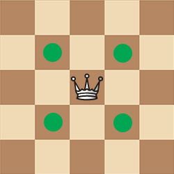

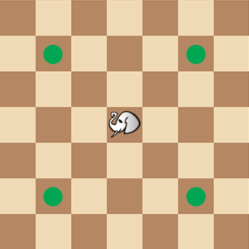

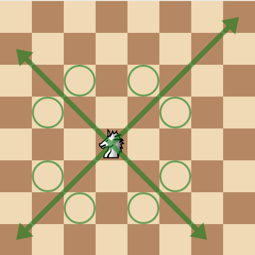

# Background Motivation

See The Chess Variant pages at https://www.chessvariants.org/

See also PyChess at https://www.pychess.org

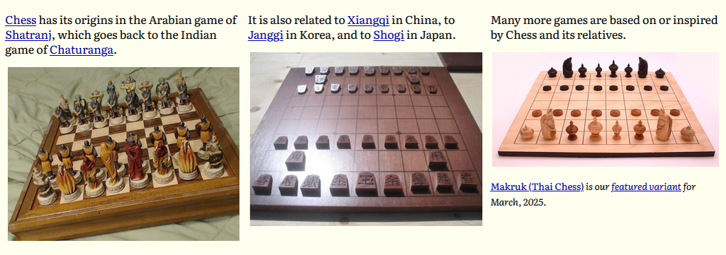

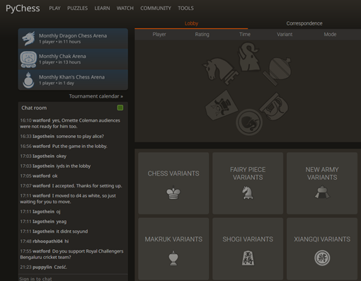

# Background Motivation

In classic chess, there is a well-established heuristic for how much different pieces are worth. A knight is worth 3 pawns, a bishop is also worth 3 pawns, a rook is worth 5, a queen is worth 9, and the king is invaluable. These valuations are useful in estimating quickly whether a trade was worth taking. For example, losing your rook, but taking two bishops is typically considered a good trade because you are losing 5 pawns of material, but your opponent is losing 6.

Many analyses have been done to improve on these estimations, as well as introduce additional context, like the knight being more in the early game than it is in the late game because there are more pieces in the early game to jump over.

# Background Motivation

In fairy chess, there are pieces like the ferz which can move diagonally but only one square at a time, and the nightrider which can move in a two-and-one pattern like the knight but any number of times in the same direction as a single move (e.g., four-and-two, or six-and-three). Relatively little analysis has been done on the valuation of these pieces. Having a larger library of pieces and their valuation estimates would bring us closer to understanding the value of pieces with arbitrary movesets, and allow for easier balancing of future chess variants.

# Previous work

User ubdip wrote on their Lichess blog at https://lichess.org/@/ubdip/blog/finding-the-value-of-pieces/PByOBlNB about an analysis where the chess engine Stockfish, an open source AI that is vastly superior to the best humans at chess, had played games against itself with varying material advantages and disadvantages for thousands of games.

The results were then fed into a logistic regression where the chance of one side winning was estimated based on the material differences on each side.

The coefficients from this logistic regression were standardized into terms of pawns, and the value of the pieces were estimated as the standardized coefficients. The code for this analysis is found on GitHub at https://github.com/ianfab/chess-variant-stats .

# Previous work

Professor Mathieu Acher wrote on his blog at http://blog.mathieuacher.com/ChessPiecesValues/ about the relative values of chess pieces as they are set as parameters in stockfish. Over the years of stockfish’s development, these values have been updated, and the pawn has slowly amassed power, especially in the endgame.

# Methodology

We’re using games from highly rated, but human, players. I’m using Stockfish and its more generalist fork Fairy Stockfish to evaluate positions from these games with all the pieces, and then again with a piece of interest removed. Then we’re taking the difference in those evaluations, both measured in centipawns, to get an estimation for the value of that piece in that situation. Then, I am averaging the evaluation differences across many positions to get Stockfish and Fairy Stockfish’s opinion of the value of those pieces across all situations.

We’re repeating these analysis for a variant of chess that is very similar to the classical game, shatranj, in order to establish some groundwork and support code for fairy chess piece valuation as a whole.

# Methodology

Here’s a real example from the dataset. (The value of pawns is inflated by a factor of 1.35 in Fairy Stockfish, so the true value is (6.78 + 0.06) / 1.35 = 5.067 )

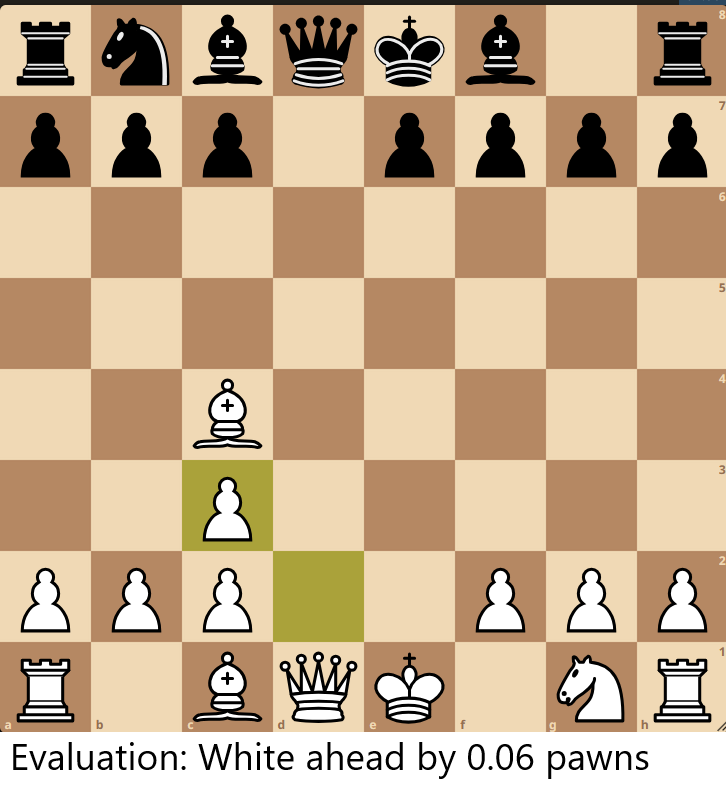

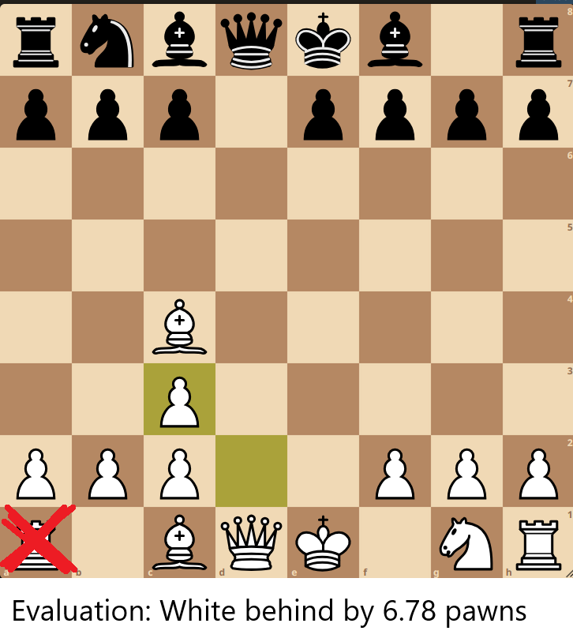

# Methodology

We then estimate the piece’s typical value either by a simple average at evaluations or by a weighted average informated by chess knowledge, or some other straightforward model like logistic regression.

It’s essentially WAR for chess, but the ‘replacement player’ is a blank space.

We took the data set we generated for standard chess and I spun it into two assignments: One for Stat 442/842/ CM 762 (Data Visualization), and one for Stat 847 (Exploratory Data Analysis). These are some results from the keys of both assignments.

# Results

Distribution of valuation by piece (corrected by 1.35 factor)

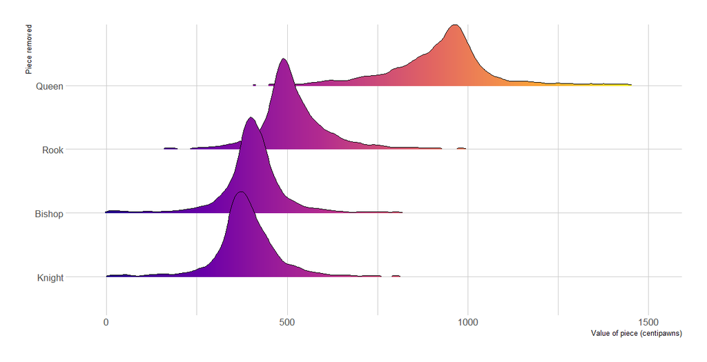

# Results

Knight value by location (corrected by 1.35 factor)

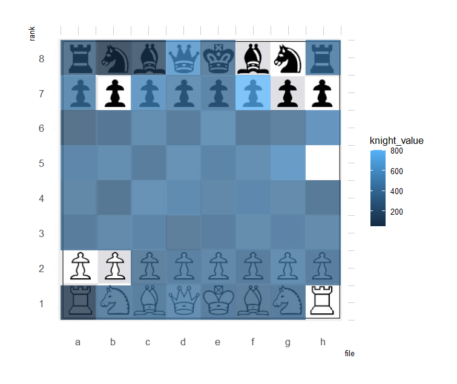

# Results

Rook value by location (corrected by 1.35 factor)

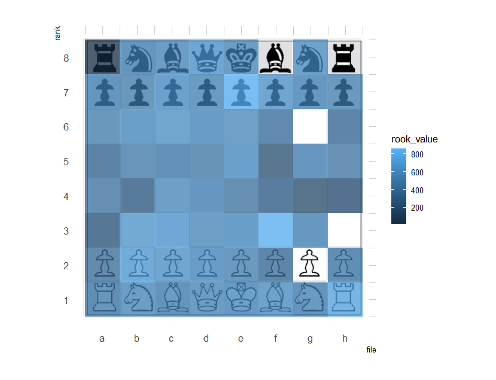

# Results

Queen value by location (corrected by 1.35 factor)

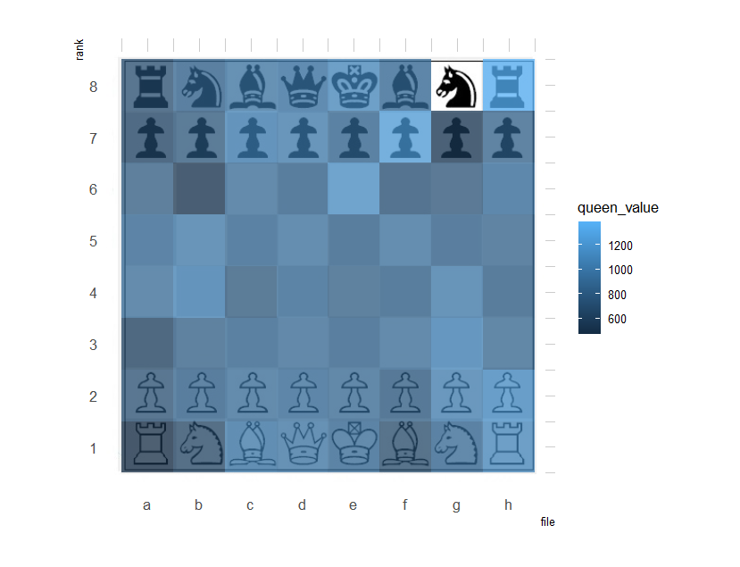

# Results

Here’s a simple model of the valuation as a function of piece and Euclidean distance from the center squares.

| Coefficients | Estimate | Std Error |
| --- | --- | --- |
| (Intercept) | 563.57 | 3.28 |
| Bishop | —- | —- |
| Knight | -23.50 | 3.87 |
| Queen | 679.78 | 4.00 |
| Rook | 161.74 | 4.46 |
| Distance | -5.16 | 1.38 |

# Results

Here’s a simple model of the valuation as a function of piece and Euclidean distance from the center squares. Intercept represents bishop in the center four squares.

| Coefficients | Estimate | Std Error |
| --- | --- | --- |
| (Intercept) | 493.33 | 28.15 |
| Bishop | —- | —- |
| Knight | -25.43 | 3.87 |
| Queen | 681.93 | 4.01 |
| Rook | 170.04 | 4.66 |
| Distance | -8.26 | 1.47 |
| Opening | 17.33 | 11.08 |
| Middle Game | 24.84 | 8.47 |
| End Game | —- | —- |
| Pieces Left | 1.74 | 0.49 |

# Future work

- Prune out the positions where evaluations is unlikely to work right, like when mate is imminent.
- Replacing one piece with another instead of just removing.
- Publicatrion. Possibly in the CRAN journal, possible as a pre-print on PyChess, and possible in the new CJS Applications section.

# Future work

**Better Stability**

Currently my code has an instability: in about 1 in every 1000 positions, or about 1 in every 20 full analyzed games, the call to the chess engine hangs and refuses to quit or return any response. This happens for both Stockfish and Fairy Stockfish, and on the same positions. My suspicion is that I’ve made a mistake in the code that converts the LAN into the FEN. Until I fix or isolate the problem, the code won’t be put on github.

# Future work

**Iterative Valuation**

I would like to investigate how the valuation parameters set by the engine affect the positional evaluations that the engine outputs. Currently, my estimates could be little more than artifacts of the initial parameters set by Stockfish and Fairy Stockfish. Ideally, I would like to have an iterative setup, in which the valuation estimates from my method are fed back into the engine as the new parameters, which will produce new valuation estimates and so on until hopefully some stable optimum is reached. My current block is that I don’t know how to interact with Stockfish to that level of complexity using the `bigchess` package yet.

# Future work

**More Variants**

I eventually want to scale this work up so that it can work on most variants currently available on Pychess. This includes variants played on boards other than 8x8 in size, boards of more than two dimensions, other classic games covered by fairy stockfish like Shogi, variants with a neutral piece or terrain like duck chess and Xiangqi respectively, and drop variants like crazyhouse. This will involve a lot more organization and coding work than I currently have capacity for.

# Future work

**More Data**

I need more fairy chess games. This can be done either by generating games by playing fairy stockfish against itself, or by collecting data from more Pychess users. Also, if there’s a variant you want to see analyzed more, play that variant more on Pychess, or propose it.

# Details: A PGN, a SAN, and a FEN walk into a bar

I am using a collection of Lichess game PGNs (portable game notation) and the `bigchess` package in R (Wojciech Rosa, https://CRAN.R-project.org/package=bigchess) to convert SANs (short algebraic notation, which is a minimalist way to describe moves in a chess match) into LANs (long algebraic notation, which explicitly states where a piece came from as well as its destination).

Then, using a custom function, I convert those LANs into FENs (Forsyth–Edwards notation, which describes the entire board state). Once I have the board described in FEN format, I can do two important things. First, I can feed the FEN of any point in the game into a chess engine like Stockfish. Second, I can make arbitrary changes to the board, like removing a piece.

# Details: A PGN, a SAN, and a FEN walk into a bar

I repeated this process for many games, for two sides, for four pieces: the first rook, knight, bishop, and queen, for each half move of the game. Here, ‘first’ means first alphabetically in algebraic notation.

I recorded the FEN board state with and without the removed piece, the position of the removed piece, the number of pieces and pawns remaining on the board (for determining when the game had entered the middle game and end game), the players’ names and Elos at the time of the match, the engine used and valuation parameters, and the URL of the game on either Lichess or Pychess.

# Details: A PGN, a SAN, and a FEN walk into a bar

The games recorded from Lichess are all classic chess, and are taken from the Lichess open database of PGNs found here: https://database.lichess.org/ . I started with classic chess for coding simplicity and to test the methods in a situation where the ground truth is already estimated by independent methods. The games recorded from Pychess are all shatranj (and later, other variants), and are taken from PGN player records on the Pychess leaderboards at https://www.pychess.org/players .

# Details: Universal Chess Interface

Hundreds of chess engines, including Stockfish and Fairy Stockfish, use the UCI, or Universal Chess Interface. Among other things, this allows an R package like `bigchess` to interface with any of these chess engines with the same input format (i.e., a FEN board state), and get the same output out, which looks like this:

```
 [1] "Fairy-Stockfish 14 by Fabian Fichter"
 [2] "readyok"
 [3] "info string classical evaluation enabled"
 [4] "info depth 1 seldepth 1 multipv 1 score cp 0 nodes 24 nps 24000 tbhits 0 time 1 pv e7e6"
 [5] "info depth 2 seldepth 2 multipv 1 score cp -7 nodes 47 nps 47000 tbhits 0 time 1 pv e7e6 b2b3"
 ...
[13] "info depth 10 seldepth 15 multipv 1 score cp -76 nodes 23456 nps 868740
tbhits 0 time 27 pv e7e5 g1f3 g8f6 b1c3 b8c6 d2d4 e5d4 f3d4"
[14] "bestmove e7e5 ponder g1f3"
```

# Details: Universal Chess Interface

The last two lines are of the most importance. The last line suggests the best move that the engine has found (`e7e5`), and what the engine expects the opponent’s next move to be (`g1f3`). By anticipating the opponent’s next move, the engine can ponder (if it is allowed to), which means it will spend the time the opponent is selecting their move to get a head start on how to respond.

The second last line gives more detailed information about what the engine is thinking. Here the engine `Fairy-Stockfish 14` has considered all (reasonable) possibilities for its next 10 moves (`depth 10`), and has started to consider the possibilities for its next 15 moves (`seldepth 15`). It considers itself be to behind by 76 centipawns (`cp -76`) on the board. The best line, and opponent’s line, that it has found so far is `e7e5 g1f3 g8f6 b1c3 b8c6 d2d4 e5d4 f3d4`.

For this project, we are mostly interested in the board/positional evaluation, here which is either `cp [integer]` for the number of centipawns ahead or behind, or `M[integer]` if the engine has found an unavoidable checkmate in `integer` moves.

# Details: Stockfish vs. Fairy Stockfish

As mentioned before, Fairy Stockfish is a fork of Stockfish which has been trained to play chess-like games with pieces that have arbitrary movesets. This flexibility allows it to be games as broad as grand chess (chess on a larger board) and shogi (a Japanese chess-like game).

Both engines support the Universal Chess Interface, but Fairy Stockfish also supports other interfaces like the Universal Shogi Interface among others (See https://github.com/fairy-stockfish/Fairy-Stockfish for details). Fairy Stockfish performs marginally slower than Stockfish, and so cannot reach quite the same depth as Stockfish in time control situations. It outperforms other generalist fairy engines, but is outperformed by the best specialist engines

(See https://github.com/fairy-stockfish/Fairy-Stockfish/wiki/Playing-strength for details)

# Older notes

I’ve been thinking about stuff like this for a while now:

Why Chess? Part 1: Smaller Boards (2016) https://www.stats-et-al.com/2016/08/why-chess-part-1-smaller-boards.html

I read this: Chess Metaphors: Artificial Intelligence and the Human Mind (2017) https://www.stats-et-al.com/2017/02/i-read-this-chess-metaphors-artificial.html

I read this: Chess Variants - Ancient, Regional and Modern (2017) https://www.stats-et-al.com/2017/02/i-read-this-chess-variants-ancient.html

Chess Variants - 960 and Really Bad Chess (2017) https://www.stats-et-al.com/2017/07/chess-variants-960-and-really-bad-chess.html

AlphaZero, Stockfish, and flexibility regarding chess variants. (2018) https://www.stats-et-al.com/2018/01/alphazero-stockfish-and-flexibility.html